[figure not shown]

# Zero Contact Branches

### Incidence relationship between types of business vs COVID indexes (Number of Negative Cases, number of confirmed cases and number of deaths)

#### November, 2020

## Objetive

Capstone project - Week 2

# 1. Introduction

## 1.1 Background

With the arrival of the pandemic, many businesses have required to accelerate their digital transformation processes, however, they have realized that this transformation is not only focused on digitizing work or reconverting their businesses, but also analyzing in depth the opportunities they have. and make an optimal management of investment resources.

For this, and especially the financial sector, has put to work seeking to better understand its environment, adapt / improve its digital processes, as well as approach vulnerable areas derived from the pandemic with the possibility of opening a new type of branch called Zero Contact.

## 1.2 Problem Statement

It has started with the exploration of a new branch expansion process based on Data Science. To do this, and due to the pandemic, you want to know how much relationship exists between the various **types of businesses** located in a geographical area vs the **Number of Negative Cases, number of confirmed cases, number of deaths** caused by COVID-19 ? With this, the correlation between the types of businesses and the indices mentioned can be determined to determine possible suitable areas for said branches.

## 1.3 Data

To consider the problem we can list the datas as below (I originally considered only 2 sources of data):

Because I live in CDMX (formelly Mexico City) in the town hall of Azcapotzalco it comes from Nahuatl *azcaputzalli* --> anthill, and *co*--> locative: meaning "en el hormiguero" *(spanish)* --> "in the anthill" *(english)* it's a pre-hispanic town.

1. **Data from Foursquare**

( https://foursquare.com/developers/apps ) what type of venues exist in the surroundings of a geographic area [Azcapotzalco].

[figure not shown]

2. **Data from [GDE (Dirección General de Epidemiología)](https://www.gob.mx/salud/acciones-y-programas/direccion-general-de-epidemiologia) in México**

Covid19 open data ( [Datos COVID-19](https://datos.covid-19.conacyt.mx/) , [DGE Open Data Mexico](https://www.gob.mx/salud/documentos/datos-abiertos-152127) ), general public information from México Government. Filter by [Azcapotzalco] on where the growth rates have been in three main metrics.  
2.1. Number of negative cases

[figure not shown]

2.2. Number of confirmed cases

[figure not shown]

2.3. Number of deaths

[figure not shown]

**Here I found a little problem !!!**  
This DGE info have no detailed data for **suburb**; by this moment only mayor is available, also the data of **Four Square** that I have, it's **suburb** level.  
So, it's not same granularity, then I have to dismiss this data. *Yeah, is my BAD*

3. **Data [Cases associated with COVID in CDMX](https://datos.cdmx.gob.mx/explore/?sort=modified&q=casos+asociados+a+covid) [Mexico City data portal](https://datos.cdmx.gob.mx/pages/home/)**

[figure not shown]

In this site, I found valued data! like locations shapes at different levels [Mexico City, Mexico City w/mayors, Suburbs of an Azcapotzalco Mayor], also many kinds of metrics, from COVID, Security, and others.

3.1. **Mayors / Districts** limits *(Delimitación de las alcaldías)*  
[Mayors / Districts limits](https://datos.cdmx.gob.mx/explore/dataset/limite-de-las-alcaldias/information/)

3.2. **Suburb** limits *(Delimitación de colonias)*  
[Suburb [Azcapotzalco] limits](https://datos.cdmx.gob.mx/explore/dataset/coloniascdmx/information/)

[figure not shown]

3.3. **Suburb** active cases of COVID-19 in Mexico City *(Casos activos de Covid-19 en Ciudad de México a nivel colonia)*  
[COVID-19 active cases](https://datos.cdmx.gob.mx/explore/dataset/covid-19-sinave-ciudad-de-mexico-a-nivel-colonia/information/?disjunctive.colonia)

3.4. **Suburb** crime DATA in Azcapotzalco *(Crime cases in Azcapotzalco by suburb)*  
[Crime DATA by Azcapotzalco](https://datos.cdmx.gob.mx/explore/dataset/carpetas-de-investigacion-pgj-de-la-ciudad-de-mexico/export/?disjunctive.ao_hechos&disjunctive.delito&refine.alcaldia_hechos=AZCAPOTZALCO) *This is only if I don't find anything in COVID-19 Data, please don't judge me =)*

## 1.4 Methodology

### Data preparation

```
Libs installed and imported!
```

```
{'encoding': 'ascii', 'confidence': 1.0, 'language': ''}
```

### Let's start with GEO Data first

```
Data D:/Proyectos/Data_MX/DATOS.CDMX/coloniascdmx_azcapotzalco.csv read into a dataframe!
```

```
Index(['COLONIA', 'ENTIDAD', 'Geo Point', 'Geo Shape', 'CVE_ALC', 'ALCALDIA',
       'CVE_COL', 'SECC_COM', 'SECC_PAR'],
      dtype='object')
```

```
Random COLONIA from list:  HUAUTLA DE LAS SALINAS (BARR)
```

|  | COLONIA | ENTIDAD | Geo Point | Geo Shape | CVE_ALC | ALCALDIA | CVE_COL | SECC_COM | SECC_PAR |
| --- | --- | --- | --- | --- | --- | --- | --- | --- | --- |
| 0 | SAN JUAN TLIHUACA (PBLO) | 9 | 19.48939757,-99.2045938841 | {"type": "Polygon", "coordinates": [[[-99.2011... | 2 | AZCAPOTZALCO | 02-079 | 233, 217, 218, 211, 208 | 209, 232, 235, 237 |
| 1 | SAN BARTOLO CAHUALTONGO (PBLO) | 9 | 19.4820316793,-99.2005770245 | {"type": "Polygon", "coordinates": [[[-99.1990... | 2 | AZCAPOTZALCO | 02-075 | 244 | 237, 290 |
| 2 | PRESIDENTE MADERO (U HAB) | 9 | 19.4958312763,-99.2017260799 | {"type": "Polygon", "coordinates": [[[-99.2022... | 2 | AZCAPOTZALCO | 02-064 | 196, 206, 207, 195 | 209 |
| 3 | LIBERTAD | 9 | 19.478276634,-99.17731252 | {"type": "Polygon", "coordinates": [[[-99.1793... | 2 | AZCAPOTZALCO | 02-044 | NaN | 94, 99 |
| 4 | DEL MAESTRO | 9 | 19.4827613752,-99.182303945 | {"type": "Polygon", "coordinates": [[[-99.1828... | 2 | AZCAPOTZALCO | 02-017 | NaN | 85, 91 |

|  | COLONIA | CVE_COL | Latitude | Longitude |
| --- | --- | --- | --- | --- |
| 0 | SAN JUAN TLIHUACA (PBLO) | 02-079 | 19.48939757 | -99.2045938841 |
| 1 | SAN BARTOLO CAHUALTONGO (PBLO) | 02-075 | 19.4820316793 | -99.2005770245 |
| 2 | PRESIDENTE MADERO (U HAB) | 02-064 | 19.4958312763 | -99.2017260799 |
| 3 | LIBERTAD | 02-044 | 19.478276634 | -99.17731252 |
| 4 | DEL MAESTRO | 02-017 | 19.4827613752 | -99.182303945 |

```
'02-079'
```

```
(111, 4)
```

### Map the points of Suburs (COLONIAS) in Azcapotzalco

#### Use geopy library to get the latitude and longitude values of Azcapotzalco.

```
The geograpical coordinate of Azcapotzalco are 19.4837824, -99.1844166.
```

#### Function for nice Popups!

Make this Notebook Trusted to load map: File -> Trust Notebook

[interactive chart not shown]

### Let's explore with COVID Data

```
Data D:/Proyectos/Data_MX/DATOS.CDMX/casos-asociados-a-covid-19-azcapotzalco.csv read into a dataframe!
```

```
Renglones/Columnas - del archivo : (31867, 47)
```

```
Index(['FECHA ACTUALIZACION', 'ID_REGISTRO', 'ORIGEN', 'SECTOR',
       'ENTIDAD UNIDAD MEDICA', 'SEXO', 'ENTIDAD NACIMIENTO',
       'ENTIDAD RESIDENCIA', 'MUNICIPIO RESIDENCIA', 'TIPO PACIENTE',
       'FECHA INGRESO', 'FECHA SINTOMAS', 'FECHA DEFUNCION', 'INTUBADO',
       'NEUMONIA', 'EDAD', 'NACIONALIDAD', 'EMBARAZO', 'HABLA LENGUA INDIGENA',
       'DIABETES', 'EPOC', 'ASMA', 'INMUNOSUPRESION', 'HIPERTENSION',
       'OTRA COMPLICACION', 'CARDIOVASCULAR', 'OBESIDAD', 'RENAL CRONICA',
       'TABAQUISMO', 'OTRO CASO', 'MIGRANTE', 'PAIS NACIONALIDAD',
       'PAIS ORIGEN', 'UNIDAD DE CUIDADOS INTENSIVOS', 'RANGO EDAD',
       'num_fallecidos', 'num_hospitalizados', 'INDIGENA', 'RESULTADO_LAB',
       'CLASIFICACION_FINAL', 'clas_final_escrita', 'confirmados',
       'sospechosos', 'negativos', 'TOMA_MUESTRA_LAB', 'TOMA_MUESTRA_ANTIGENO',
       'RESULTADO_ANTIGENO'],
      dtype='object')
```

```
(31867, 47)
```

|  | ID_REGISTRO | MUNICIPIO RESIDENCIA | SEXO | EDAD | RANGO EDAD | FECHA DEFUNCION | confirmados | negativos |
| --- | --- | --- | --- | --- | --- | --- | --- | --- |
| 0 | 1524fc | Azcapotzalco | HOMBRE | 60 | 51-60 | NaN | confirmados | NaN |
| 1 | 1b3cce | Azcapotzalco | MUJER | 47 | 41-50 | NaN | confirmados | NaN |
| 2 | 02adbb | Azcapotzalco | MUJER | 17 | 16-20 | NaN | confirmados | NaN |
| 3 | 000090 | Azcapotzalco | HOMBRE | 51 | 51-60 | NaN | confirmados | NaN |
| 4 | 10467e | Azcapotzalco | HOMBRE | 37 | 31-40 | NaN | confirmados | NaN |

```
ID_REGISTRO             object
MUNICIPIO RESIDENCIA    object
SEXO                    object
EDAD                     int64
RANGO EDAD              object
FECHA DEFUNCION         object
confirmados             object
negativos               object
dtype: object
```

```
nan
```

### Here I tried to fix my problem

I will implement a function to insert RANDON **Suburb [COLONIA]** -- also include 'deaths" for cases where **'FECHA DEFUNCION'** is not null  
So, will be possible to match VENUES from Four Square Data.  
*By the way, this takes me half of a day!*

# here I am!!

|  | ID_REGISTRO | MUNICIPIO RESIDENCIA | SEXO | EDAD | RANGO EDAD | FECHA DEFUNCION | confirmados | negativos | COLONIA |
| --- | --- | --- | --- | --- | --- | --- | --- | --- | --- |
| 0 | 1524fc | Azcapotzalco | HOMBRE | 60 | 51-60 | NaN | confirmados | NaN | COSMOPOLITA |
| 1 | 1b3cce | Azcapotzalco | MUJER | 47 | 41-50 | NaN | confirmados | NaN | EL ROSARIO C (U HAB) |
| 2 | 02adbb | Azcapotzalco | MUJER | 17 | 16-20 | NaN | confirmados | NaN | ROSENDO SALAZAR (CONJ HAB) |
| 3 | 000090 | Azcapotzalco | HOMBRE | 51 | 51-60 | NaN | confirmados | NaN | EL JAGUEY-ESTACION PANTACO |
| 4 | 10467e | Azcapotzalco | HOMBRE | 37 | 31-40 | NaN | confirmados | NaN | SAN BERNABE (BARR) |

```
ID_REGISTRO             object
MUNICIPIO RESIDENCIA    object
SEXO                    object
EDAD                     int64
RANGO EDAD              object
FECHA DEFUNCION         object
confirmados             object
negativos               object
COLONIA                 object
dtype: object
```

### Let's check main metrics in COVID Data with FAKE [COLONIA]

```
(31867, 9)
```

```
COLONIA                           SEXO
NEXTENGO (BARR)                   MUJER     184
SAN PABLO XALPA (U HAB)           MUJER     181
CUITLHUAC 1 Y 2 (U HAB)           MUJER     180
UN HOGAR PARA CADA TRABAJADOR     MUJER     177
NUEVA ESPAA                       MUJER     176
                                           ...
PEMEX PRADOS DEL ROSARIO (U HAB)  HOMBRE    116
MONTE ALTO                        HOMBRE    114
EUZKADI                           HOMBRE    113
CRUZ ROJA TEPANTONGO (U HAB)      HOMBRE    112
SAN FRANCISCO TETECALA (PBLO)     HOMBRE     95
Length: 222, dtype: int64
```

#### Number of Male / Female records

Female 16918  
Male 14949

```
RANGO EDAD
31-40         6701
41-50         6313
21-30         6067
51-60         5440
61-70         2864
71-80         1373
16-20         1227
06-15          950
81-90          496
0-05           336
91-100          91
dtype: int64
```

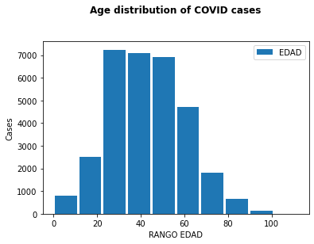

#### Records by Aged Range

Age Range --> Records 0-05 --> 336  
06-15 --> 950  
16-20 --> 1227  
21-30 --> 6067  
31-40 --> 6701  
41-50 --> 6313  
51-60 --> 5440  
61-70 --> 2864  
71-80 --> 1373  
81-90 --> 496  
91-100 --> 91

```
COLONIA                           negativos
SAN PABLO XALPA (U HAB)           negativos    182
HOGARES FERROCARRILEROS (U HAB)   negativos    171
MIGUEL HIDALGO (U HAB)            negativos    163
ROSENDO SALAZAR (CONJ HAB)        negativos    161
FRANCISCO VILLA (U HAB)           negativos    161
                                              ...
VILLAS AZCAPOTZALCO (U HAB)       negativos    123
PRO HOGAR II                      negativos    119
SAN FRANCISCO TETECALA (PBLO)     negativos    119
PEMEX PRADOS DEL ROSARIO (U HAB)  negativos    119
LA PRECIOSA                       negativos    112
Length: 111, dtype: int64
```

#### 2.1. Number of negative cases (15718)

```
COLONIA                              confirmados
EL ROSARIO C (U HAB)                 confirmados    139
ECOLOGICA NOVEDADES IMPACTO (U HAB)  confirmados    134
ALDANA                               confirmados    125
LIBERTAD                             confirmados    125
PORVENIR                             confirmados    124
                                                   ...
COSMOPOLITA (AMPL)                   confirmados     89
SAN MATEO                            confirmados     88
PEMEX PRADOS DEL ROSARIO (U HAB)     confirmados     87
SAN JUAN TLIHUACA (PBLO)             confirmados     86
FERRERIA                             confirmados     83
Length: 111, dtype: int64
```

#### 2.2 Number of confirmed cases (11877)

```
COLONIA  FECHA DEFUNCION
True     False              30393
         True                1474
dtype: int64
```

#### 2.3. Number of deaths (1474)

|  | COLONIA | FECHA DEFUNCION | confirmados | negativos |
| --- | --- | --- | --- | --- |
| 0 | COSMOPOLITA | NaN | confirmados | NaN |
| 1 | EL ROSARIO C (U HAB) | NaN | confirmados | NaN |
| 2 | ROSENDO SALAZAR (CONJ HAB) | NaN | confirmados | NaN |
| 3 | EL JAGUEY-ESTACION PANTACO | NaN | confirmados | NaN |
| 4 | SAN BERNABE (BARR) | NaN | confirmados | NaN |

```
COLONIA                              confirmados
EL ROSARIO C (U HAB)                 confirmados    139
ECOLOGICA NOVEDADES IMPACTO (U HAB)  confirmados    134
ALDANA                               confirmados    125
LIBERTAD                             confirmados    125
PORVENIR                             confirmados    124
                                                   ...
COSMOPOLITA (AMPL)                   confirmados     89
SAN MATEO                            confirmados     88
PEMEX PRADOS DEL ROSARIO (U HAB)     confirmados     87
SAN JUAN TLIHUACA (PBLO)             confirmados     86
FERRERIA                             confirmados     83
Length: 111, dtype: int64
```

#### After rearrange data let's count, Which Suburb [COLONIA] have most cases with confirmed of COVID ?

```
(array([0, 1, 2, 3, 4, 5, 6, 7, 8, 9]),
 [Text(0, 0, 'EL ROSARIO C (U HAB)'),
```

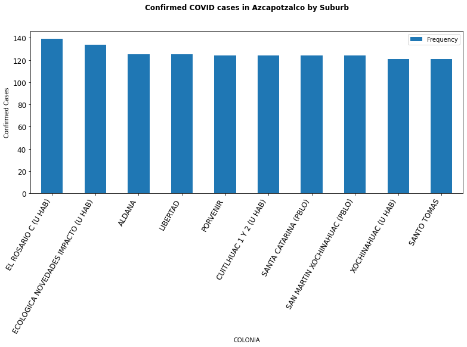

#### Which Suburb [COLONIA] have most cases with Negative of COVID ?

```
(array([0, 1, 2, 3, 4, 5, 6, 7, 8, 9]),
 [Text(0, 0, 'SAN PABLO XALPA (U HAB)'),
```

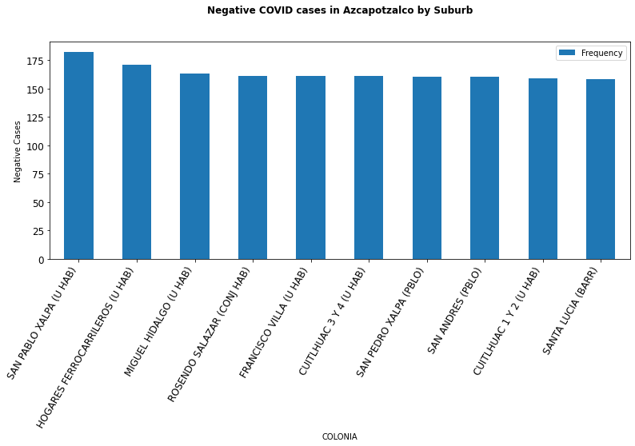

#### Which Suburb [COLONIA] have most cases with deaths of COVID ?

[output not shown]

[figure not shown]

|  | COLONIA | FECHA DEFUNCION | confirmados | negativos |
| --- | --- | --- | --- | --- |
| 0 | AGUILERA | 12 | 113 | 128 |
| 1 | ALDANA | 20 | 125 | 136 |
| 2 | AMPLIACION PETROLERA | 11 | 91 | 141 |
| 3 | ANGEL ZIMBRON | 13 | 111 | 137 |
| 4 | ARENAL | 12 | 115 | 150 |
| ... | ... | ... | ... | ... |
| 106 | TRABAJADORES DEL HIERRO | 12 | 102 | 141 |
| 107 | UN HOGAR PARA CADA TRABAJADOR | 15 | 107 | 157 |
| 108 | VICTORIA DE LAS DEMOCRACIAS | 15 | 90 | 158 |
| 109 | VILLAS AZCAPOTZALCO (U HAB) | 10 | 115 | 123 |
| 110 | XOCHINAHUAC (U HAB) | 11 | 121 | 134 |

111 rows × 4 columns

### Now, lets work with Four Square - GEO data

```
Index(['COLONIA', 'CVE_COL', 'Latitude', 'Longitude'], dtype='object')
```

|  | COLONIA | CVE_COL | Latitude | Longitude |
| --- | --- | --- | --- | --- |
| 0 | SAN JUAN TLIHUACA (PBLO) | 02-079 | 19.48939757 | -99.2045938841 |
| 1 | SAN BARTOLO CAHUALTONGO (PBLO) | 02-075 | 19.4820316793 | -99.2005770245 |
| 2 | PRESIDENTE MADERO (U HAB) | 02-064 | 19.4958312763 | -99.2017260799 |
| 3 | LIBERTAD | 02-044 | 19.478276634 | -99.17731252 |
| 4 | DEL MAESTRO | 02-017 | 19.4827613752 | -99.182303945 |

[output not shown]

```
'https://api.foursquare.com/v2/venues/explore?&client_id=AUXXJIVWPBBNH13GQCWVUNYJQQ4Q3TM3LPR4QKPID3SVXLCL&client_secret=MIZGFL1VO2UQI5NKCGDZXEZIGPVAV4HVHZDPOV5EBKV5GGVQ&v=20180605&ll=19.4628408836,-99.1679884039&radius=500&limit=100'
```

Send the GET request and examine the resutls

[output not shown]

[output cut: 2706 more lines]

[output not shown]

From the Foursquare lab in the previous module, we know that all the information is in the *items* key. Before we proceed, let's borrow the **get_category_type** function from the Foursquare lab.

Now we are ready to clean the json and structure it into a *pandas* dataframe.

|  | name | categories | lat | lng |
| --- | --- | --- | --- | --- |
| 0 | Tacos Mary | Taco Place | 19.464084 | -99.169519 |
| 1 | Odory Repostería | Bakery | 19.463249 | -99.165951 |
| 2 | Mardiz snack and beer | Beer Garden | 19.462174 | -99.168723 |
| 3 | Academia Sombae Do Nueva Santa Maria | Martial Arts School | 19.461213 | -99.169234 |
| 4 | The Beer Company Azcapotzalco | Brewery | 19.463209 | -99.166421 |

```
96 venues were returned by Foursquare.
```

## Explore Neighborhoods in 'Azcapotzalco'

#### Let's copy the function from top and repeat the same process to all Azcapotzalco

#### Now write the code to run the above function on each neighborhood and create a new dataframe called _azc*venues*.

```
SAN JUAN TLIHUACA (PBLO)
SAN BARTOLO CAHUALTONGO (PBLO)
PRESIDENTE MADERO (U HAB)
LIBERTAD
DEL MAESTRO
NUEVA SANTA MARIA
PORVENIR
SAN ANDRES (BARR)
SAN ANDRES (PBLO)
TLATILCO (U HAB)
LOS REYES (BARR)
JARDIN AZPEITIA
FERRERIA
TEZOZOMOC
XOCHINAHUAC (U HAB)
PROVIDENCIA
PASTEROS
IGNACIO ALLENDE
DEL GAS
EX-HACIENDA EL ROSARIO
CUITLHUAC 1 Y 2 (U HAB)
CLAVERIA
ALDANA
COSMOPOLITA
AMPLIACION PETROLERA
HUAUTLA DE LAS SALINAS (BARR)
CRUZ ROJA TEPANTONGO (U HAB)
PEMEX PRADOS DEL ROSARIO (U HAB)
LA RAZA
NUEVA EL ROSARIO
TLATILCO
SANTA INES
INDUSTRIAL VALLEJO (U HAB)
EL JAGUEY-ESTACION PANTACO
COSMOPOLITA (AMPL)
PRO HOGAR I
SANTIAGO AHUIZOTLA (PBLO)
MANUEL RIVERA ANAYA CROC I (U HAB)
TIERRA NUEVA
SAN FRANCISCO TETECALA (PBLO)
```

[output cut: 56 more lines]

```
AGUILERA
ECOLOGICA NOVEDADES IMPACTO (U HAB)
EUZKADI
JARDINES CEYLAN (U HAB)
PRADOS DEL ROSARIO
LIBERACION
SANTA MARIA MALINALCO (PBLO)
COLTONGO
REYNOSA TAMAULIPAS
SAN ALVARO
SAN ANDRES DE LAS SALINAS (PBLO)
ROSENDO SALAZAR (CONJ HAB)
SANTA BARBARA (PBLO)
SAN SEBASTIAN
SINDICATO MEXICANO DE ELECTRICISTAS
```

```
(8642, 7)
```

|  | Colonia | Colonia Latitude | Colonia Longitude | Venue | Venue Latitude | Venue Longitude | Venue Category |
| --- | --- | --- | --- | --- | --- | --- | --- |
| 0 | SAN JUAN TLIHUACA (PBLO) | 19.48939757 | -99.2045938841 | Tacos Del Parque | 19.491002 | -99.207536 | Taco Place |
| 1 | SAN JUAN TLIHUACA (PBLO) | 19.48939757 | -99.2045938841 | Barbacoa El Borreghito Hidalguense | 19.489833 | -99.203466 | Taco Place |
| 2 | SAN JUAN TLIHUACA (PBLO) | 19.48939757 | -99.2045938841 | la michoacana | 19.485082 | -99.200502 | Ice Cream Shop |
| 3 | SAN JUAN TLIHUACA (PBLO) | 19.48939757 | -99.2045938841 | Taqueria Muy Salsas | 19.494940 | -99.200127 | Taco Place |
| 4 | SAN JUAN TLIHUACA (PBLO) | 19.48939757 | -99.2045938841 | Los Pit's México | 19.484625 | -99.198399 | Food Truck |

#### Which Venue Category have most number of Venues ?

```
(array([0, 1, 2, 3, 4, 5, 6, 7, 8, 9]),
 [Text(0, 0, 'Mexican Restaurant'),
```

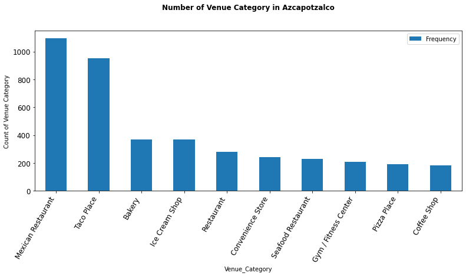

Let's check how many venues were returned for each suburb

| Colonia | Colonia Latitude | Colonia Longitude | Venue | Venue Latitude | Venue Longitude | Venue Category |
| --- | --- | --- | --- | --- | --- | --- |
| AGUILERA | 89 | 89 | 89 | 89 | 89 | 89 |
| ALDANA | 100 | 100 | 100 | 100 | 100 | 100 |
| AMPLIACION PETROLERA | 94 | 94 | 94 | 94 | 94 | 94 |
| ANGEL ZIMBRON | 93 | 93 | 93 | 93 | 93 | 93 |
| ARENAL | 100 | 100 | 100 | 100 | 100 | 100 |
| ... | ... | ... | ... | ... | ... | ... |
| TRABAJADORES DEL HIERRO | 93 | 93 | 93 | 93 | 93 | 93 |
| UN HOGAR PARA CADA TRABAJADOR | 71 | 71 | 71 | 71 | 71 | 71 |
| VICTORIA DE LAS DEMOCRACIAS | 100 | 100 | 100 | 100 | 100 | 100 |
| VILLAS AZCAPOTZALCO (U HAB) | 88 | 88 | 88 | 88 | 88 | 88 |
| XOCHINAHUAC (U HAB) | 54 | 54 | 54 | 54 | 54 | 54 |

111 rows × 6 columns

#### Let's find out how many unique categories can be curated from all the returned venues

```
There are 197 uniques categories.
```

## Analyze Each Suburb

|  | Colonia | ATM | Accessories Store | American Restaurant | Arcade | Argentinian Restaurant | Art Gallery | Art Museum | Arts & Crafts Store | Arts & Entertainment | ... | Trade School | Trail | Train Station | Tree | Vegetarian / Vegan Restaurant | Veterinarian | Warehouse | Warehouse Store | Wings Joint | Yoga Studio |
| --- | --- | --- | --- | --- | --- | --- | --- | --- | --- | --- | --- | --- | --- | --- | --- | --- | --- | --- | --- | --- | --- |
| 0 | SAN JUAN TLIHUACA (PBLO) | 0 | 0 | 0 | 0 | 0 | 0 | 0 | 0 | 0 | ... | 0 | 0 | 0 | 0 | 0 | 0 | 0 | 0 | 0 | 0 |
| 1 | SAN JUAN TLIHUACA (PBLO) | 0 | 0 | 0 | 0 | 0 | 0 | 0 | 0 | 0 | ... | 0 | 0 | 0 | 0 | 0 | 0 | 0 | 0 | 0 | 0 |
| 2 | SAN JUAN TLIHUACA (PBLO) | 0 | 0 | 0 | 0 | 0 | 0 | 0 | 0 | 0 | ... | 0 | 0 | 0 | 0 | 0 | 0 | 0 | 0 | 0 | 0 |
| 3 | SAN JUAN TLIHUACA (PBLO) | 0 | 0 | 0 | 0 | 0 | 0 | 0 | 0 | 0 | ... | 0 | 0 | 0 | 0 | 0 | 0 | 0 | 0 | 0 | 0 |
| 4 | SAN JUAN TLIHUACA (PBLO) | 0 | 0 | 0 | 0 | 0 | 0 | 0 | 0 | 0 | ... | 0 | 0 | 0 | 0 | 0 | 0 | 0 | 0 | 0 | 0 |

5 rows × 198 columns

```
(8642, 198)
```

#### Next, let's group rows by suburb and by taking the mean of the frequency of occurrence of each category

|  | Colonia | ATM | Accessories Store | American Restaurant | Arcade | Argentinian Restaurant | Art Gallery | Art Museum | Arts & Crafts Store | Arts & Entertainment | ... | Trade School | Trail | Train Station | Tree | Vegetarian / Vegan Restaurant | Veterinarian | Warehouse | Warehouse Store | Wings Joint | Yoga Studio |
| --- | --- | --- | --- | --- | --- | --- | --- | --- | --- | --- | --- | --- | --- | --- | --- | --- | --- | --- | --- | --- | --- |
| 0 | AGUILERA | 0.0 | 0.000000 | 0.000000 | 0.000000 | 0.000000 | 0.00 | 0.0 | 0.000000 | 0.000000 | ... | 0.0 | 0.000000 | 0.0 | 0.000000 | 0.000000 | 0.000000 | 0.0 | 0.011236 | 0.056180 | 0.000000 |
| 1 | ALDANA | 0.0 | 0.000000 | 0.000000 | 0.000000 | 0.000000 | 0.00 | 0.0 | 0.000000 | 0.000000 | ... | 0.0 | 0.000000 | 0.0 | 0.000000 | 0.000000 | 0.000000 | 0.0 | 0.010000 | 0.020000 | 0.000000 |
| 2 | AMPLIACION PETROLERA | 0.0 | 0.000000 | 0.000000 | 0.000000 | 0.000000 | 0.00 | 0.0 | 0.000000 | 0.000000 | ... | 0.0 | 0.000000 | 0.0 | 0.000000 | 0.010638 | 0.010638 | 0.0 | 0.000000 | 0.010638 | 0.000000 |
| 3 | ANGEL ZIMBRON | 0.0 | 0.000000 | 0.000000 | 0.000000 | 0.010753 | 0.00 | 0.0 | 0.000000 | 0.010753 | ... | 0.0 | 0.000000 | 0.0 | 0.010753 | 0.000000 | 0.000000 | 0.0 | 0.000000 | 0.010753 | 0.010753 |
| 4 | ARENAL | 0.0 | 0.000000 | 0.000000 | 0.000000 | 0.000000 | 0.00 | 0.0 | 0.000000 | 0.000000 | ... | 0.0 | 0.000000 | 0.0 | 0.000000 | 0.000000 | 0.000000 | 0.0 | 0.010000 | 0.040000 | 0.000000 |
| ... | ... | ... | ... | ... | ... | ... | ... | ... | ... | ... | ... | ... | ... | ... | ... | ... | ... | ... | ... | ... | ... |
| 106 | TRABAJADORES DEL HIERRO | 0.0 | 0.000000 | 0.000000 | 0.000000 | 0.010753 | 0.00 | 0.0 | 0.010753 | 0.000000 | ... | 0.0 | 0.000000 | 0.0 | 0.000000 | 0.000000 | 0.000000 | 0.0 | 0.000000 | 0.021505 | 0.000000 |
| 107 | UN HOGAR PARA CADA TRABAJADOR | 0.0 | 0.000000 | 0.000000 | 0.000000 | 0.000000 | 0.00 | 0.0 | 0.000000 | 0.000000 | ... | 0.0 | 0.014085 | 0.0 | 0.000000 | 0.000000 | 0.000000 | 0.0 | 0.000000 | 0.042254 | 0.000000 |
| 108 | VICTORIA DE LAS DEMOCRACIAS | 0.0 | 0.000000 | 0.000000 | 0.000000 | 0.000000 | 0.01 | 0.0 | 0.000000 | 0.000000 | ... | 0.0 | 0.000000 | 0.0 | 0.000000 | 0.000000 | 0.010000 | 0.0 | 0.010000 | 0.000000 | 0.000000 |
| 109 | VILLAS AZCAPOTZALCO (U HAB) | 0.0 | 0.000000 | 0.000000 | 0.011364 | 0.000000 | 0.00 | 0.0 | 0.000000 | 0.000000 | ... | 0.0 | 0.000000 | 0.0 | 0.000000 | 0.000000 | 0.011364 | 0.0 | 0.000000 | 0.000000 | 0.000000 |
| 110 | XOCHINAHUAC (U HAB) | 0.0 | 0.018519 | 0.018519 | 0.000000 | 0.000000 | 0.00 | 0.0 | 0.000000 | 0.000000 | ... | 0.0 | 0.000000 | 0.0 | 0.000000 | 0.000000 | 0.000000 | 0.0 | 0.000000 | 0.000000 | 0.000000 |

111 rows × 198 columns

#### Let's print each suburb along with the top 3 most common venues

```
---- AGUILERA ----
                venue  freq
0          Taco Place  0.17
1  Mexican Restaurant  0.07
2         Wings Joint  0.06


---- ALDANA ----
                venue  freq
0          Taco Place  0.18
1  Mexican Restaurant  0.12
2  Seafood Restaurant  0.06


---- AMPLIACION PETROLERA ----
                venue  freq
0  Mexican Restaurant  0.15
1          Taco Place  0.10
2              Bakery  0.09


---- ANGEL ZIMBRON ----
                venue  freq
0  Mexican Restaurant  0.22
1          Taco Place  0.09
2         Coffee Shop  0.04


---- ARENAL ----
                  venue  freq
0    Mexican Restaurant  0.07
1  Gym / Fitness Center  0.07
2            Taco Place  0.06


---- CENTRO DE AZCAPOTZALCO ----
                venue  freq
0  Mexican Restaurant  0.19
1              Bakery  0.06
2      Ice Cream Shop  0.05
```

[output cut: 720 more lines]

```
2      Ice Cream Shop  0.08


---- VILLAS AZCAPOTZALCO (U HAB) ----
                venue  freq
0  Mexican Restaurant  0.20
1          Taco Place  0.12
2              Bakery  0.06


---- XOCHINAHUAC (U HAB) ----
            venue  freq
0      Taco Place  0.15
1            Park  0.07
2  Sandwich Place  0.04
```

#### Let's put that into a *pandas* dataframe

First, let's write a function to sort the venues in descending order.

Now let's create the new dataframe and display the top 5 venues for each neighborhood.

|  | COLONIA | 1st Most Common Venue | 2nd Most Common Venue | 3rd Most Common Venue | 4th Most Common Venue | 5th Most Common Venue |
| --- | --- | --- | --- | --- | --- | --- |
| 0 | AGUILERA | Taco Place | Mexican Restaurant | Wings Joint | Seafood Restaurant | Convenience Store |
| 1 | ALDANA | Taco Place | Mexican Restaurant | Restaurant | Seafood Restaurant | Gym / Fitness Center |
| 2 | AMPLIACION PETROLERA | Mexican Restaurant | Taco Place | Bakery | Convenience Store | BBQ Joint |
| 3 | ANGEL ZIMBRON | Mexican Restaurant | Taco Place | Coffee Shop | Bakery | Ice Cream Shop |
| 4 | ARENAL | Mexican Restaurant | Gym / Fitness Center | Taco Place | Restaurant | Café |

```
(111, 6)
```

|  | COLONIA | 1st Most Common Venue | 2nd Most Common Venue | 3rd Most Common Venue | 4th Most Common Venue | 5th Most Common Venue |
| --- | --- | --- | --- | --- | --- | --- |
| 0 | AGUILERA | Taco Place | Mexican Restaurant | Wings Joint | Seafood Restaurant | Convenience Store |
| 1 | ALDANA | Taco Place | Mexican Restaurant | Restaurant | Seafood Restaurant | Gym / Fitness Center |
| 2 | AMPLIACION PETROLERA | Mexican Restaurant | Taco Place | Bakery | Convenience Store | BBQ Joint |
| 3 | ANGEL ZIMBRON | Mexican Restaurant | Taco Place | Coffee Shop | Bakery | Ice Cream Shop |
| 4 | ARENAL | Mexican Restaurant | Gym / Fitness Center | Taco Place | Restaurant | Café |

```
COLONIA                  object
1st Most Common Venue    object
2nd Most Common Venue    object
3rd Most Common Venue    object
4th Most Common Venue    object
5th Most Common Venue    object
dtype: object
```

```
COLONIA            object
FECHA DEFUNCION     int64
confirmados         int64
negativos           int64
dtype: object
```

#### Let's join azc_merged + COVID into a *pandas* dataframe

```
(111, 201)
```

|  | COLONIA | ATM | Accessories Store | American Restaurant | Arcade | Argentinian Restaurant | Art Gallery | Art Museum | Arts & Crafts Store | Arts & Entertainment | ... | Tree | Vegetarian / Vegan Restaurant | Veterinarian | Warehouse | Warehouse Store | Wings Joint | Yoga Studio | FECHA DEFUNCION | confirmados | negativos |
| --- | --- | --- | --- | --- | --- | --- | --- | --- | --- | --- | --- | --- | --- | --- | --- | --- | --- | --- | --- | --- | --- |
| 0 | AGUILERA | 0.0 | 0.0 | 0.0 | 0.0 | 0.000000 | 0.0 | 0.0 | 0.0 | 0.000000 | ... | 0.000000 | 0.000000 | 0.000000 | 0.0 | 0.011236 | 0.056180 | 0.000000 | 12 | 113 | 128 |
| 1 | ALDANA | 0.0 | 0.0 | 0.0 | 0.0 | 0.000000 | 0.0 | 0.0 | 0.0 | 0.000000 | ... | 0.000000 | 0.000000 | 0.000000 | 0.0 | 0.010000 | 0.020000 | 0.000000 | 20 | 125 | 136 |
| 2 | AMPLIACION PETROLERA | 0.0 | 0.0 | 0.0 | 0.0 | 0.000000 | 0.0 | 0.0 | 0.0 | 0.000000 | ... | 0.000000 | 0.010638 | 0.010638 | 0.0 | 0.000000 | 0.010638 | 0.000000 | 11 | 91 | 141 |
| 3 | ANGEL ZIMBRON | 0.0 | 0.0 | 0.0 | 0.0 | 0.010753 | 0.0 | 0.0 | 0.0 | 0.010753 | ... | 0.010753 | 0.000000 | 0.000000 | 0.0 | 0.000000 | 0.010753 | 0.010753 | 13 | 111 | 137 |
| 4 | ARENAL | 0.0 | 0.0 | 0.0 | 0.0 | 0.000000 | 0.0 | 0.0 | 0.0 | 0.000000 | ... | 0.000000 | 0.000000 | 0.000000 | 0.0 | 0.010000 | 0.040000 | 0.000000 | 12 | 115 | 150 |

5 rows × 201 columns

## Cluster Suburb [COLONIA]

[output not shown]

[output cut: 615 more lines]

[output not shown]

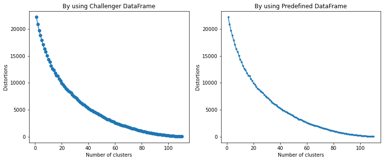

```
array([6, 7, 0, 1, 4, 9, 6, 8, 0, 8])
```

|  | Cluster Labels | COLONIA | 1st Most Common Venue | 2nd Most Common Venue | 3rd Most Common Venue | 4th Most Common Venue | 5th Most Common Venue |
| --- | --- | --- | --- | --- | --- | --- | --- |
| 0 | 6 | AGUILERA | Taco Place | Mexican Restaurant | Wings Joint | Seafood Restaurant | Convenience Store |
| 1 | 7 | ALDANA | Taco Place | Mexican Restaurant | Restaurant | Seafood Restaurant | Gym / Fitness Center |
| 2 | 0 | AMPLIACION PETROLERA | Mexican Restaurant | Taco Place | Bakery | Convenience Store | BBQ Joint |
| 3 | 1 | ANGEL ZIMBRON | Mexican Restaurant | Taco Place | Coffee Shop | Bakery | Ice Cream Shop |
| 4 | 4 | ARENAL | Mexican Restaurant | Gym / Fitness Center | Taco Place | Restaurant | Café |

|  | Cluster Labels | COLONIA | 1st Most Common Venue | 2nd Most Common Venue | 3rd Most Common Venue | 4th Most Common Venue | 5th Most Common Venue | FECHA DEFUNCION | confirmados | negativos |
| --- | --- | --- | --- | --- | --- | --- | --- | --- | --- | --- |
| 0 | 6 | AGUILERA | Taco Place | Mexican Restaurant | Wings Joint | Seafood Restaurant | Convenience Store | 12 | 113 | 128 |
| 1 | 7 | ALDANA | Taco Place | Mexican Restaurant | Restaurant | Seafood Restaurant | Gym / Fitness Center | 20 | 125 | 136 |
| 2 | 0 | AMPLIACION PETROLERA | Mexican Restaurant | Taco Place | Bakery | Convenience Store | BBQ Joint | 11 | 91 | 141 |
| 3 | 1 | ANGEL ZIMBRON | Mexican Restaurant | Taco Place | Coffee Shop | Bakery | Ice Cream Shop | 13 | 111 | 137 |
| 4 | 4 | ARENAL | Mexican Restaurant | Gym / Fitness Center | Taco Place | Restaurant | Café | 12 | 115 | 150 |

|  | Cluster Labels | COLONIA | 1st Most Common Venue | 2nd Most Common Venue | 3rd Most Common Venue | 4th Most Common Venue | 5th Most Common Venue | FECHA DEFUNCION | confirmados | negativos | CVE_COL_x | Latitude_x | Longitude_x | CVE_COL_y | Latitude_y | Longitude_y |
| --- | --- | --- | --- | --- | --- | --- | --- | --- | --- | --- | --- | --- | --- | --- | --- | --- |
| 0 | 6 | AGUILERA | Taco Place | Mexican Restaurant | Wings Joint | Seafood Restaurant | Convenience Store | 12 | 113 | 128 | 02-001 | 19.4728453807 | -99.1557459509 | 02-001 | 19.4728453807 | -99.1557459509 |
| 1 | 7 | ALDANA | Taco Place | Mexican Restaurant | Restaurant | Seafood Restaurant | Gym / Fitness Center | 20 | 125 | 136 | 02-002 | 19.4707366167 | -99.1499968041 | 02-002 | 19.4707366167 | -99.1499968041 |
| 2 | 0 | AMPLIACION PETROLERA | Mexican Restaurant | Taco Place | Bakery | Convenience Store | BBQ Joint | 11 | 91 | 141 | 02-003 | 19.4830379083 | -99.1953133848 | 02-003 | 19.4830379083 | -99.1953133848 |
| 3 | 1 | ANGEL ZIMBRON | Mexican Restaurant | Taco Place | Coffee Shop | Bakery | Ice Cream Shop | 13 | 111 | 137 | 02-005 | 19.4677940841 | -99.1891178561 | 02-005 | 19.4677940841 | -99.1891178561 |
| 4 | 4 | ARENAL | Mexican Restaurant | Gym / Fitness Center | Taco Place | Restaurant | Café | 12 | 115 | 150 | 02-006 | 19.4652942835 | -99.1520094444 | 02-006 | 19.4652942835 | -99.1520094444 |

```
(111, 16)
```

```
The geograpical coordinate of Azcapotzalco are 19.4837824, -99.1844166.
```

```
<folium.map.LayerControl at 0x255463cb5c0>
```

Make this Notebook Trusted to load map: File -> Trust Notebook

[interactive chart not shown]

|  | COLONIA | 1st Most Common Venue | 2nd Most Common Venue | 3rd Most Common Venue | 4th Most Common Venue | 5th Most Common Venue | FECHA DEFUNCION | confirmados | negativos |
| --- | --- | --- | --- | --- | --- | --- | --- | --- | --- |
| 2 | AMPLIACION PETROLERA | Mexican Restaurant | Taco Place | Bakery | Convenience Store | BBQ Joint | 11 | 91 | 141 |
| 8 | COSMOPOLITA | Taco Place | Mexican Restaurant | Food Truck | Convenience Store | Burger Joint | 12 | 103 | 149 |
| 10 | CRUZ ROJA TEPANTONGO (U HAB) | Mexican Restaurant | Taco Place | Coffee Shop | Fast Food Restaurant | Seafood Restaurant | 8 | 104 | 139 |
| 17 | DEMET (U HAB) | Mexican Restaurant | Taco Place | Pizza Place | Food Truck | Breakfast Spot | 10 | 102 | 144 |
| 21 | EL ROSARIO B (U HAB) | Taco Place | Mexican Restaurant | Bakery | Lighthouse | Multiplex | 14 | 104 | 141 |
| 28 | FUENTES DE AZCAPOTZALCO-PARQUES DE AZCAPOTZALC... | Mexican Restaurant | Taco Place | Ice Cream Shop | Bakery | Gym / Fitness Center | 15 | 102 | 145 |
| 35 | JARDIN AZPEITIA | Mexican Restaurant | Restaurant | Taco Place | Convenience Store | Burger Joint | 8 | 95 | 143 |
| 36 | JARDINES CEYLAN (U HAB) | Taco Place | Food Truck | Restaurant | Convenience Store | Mexican Restaurant | 15 | 99 | 147 |
| 42 | LOS REYES (BARR) | Mexican Restaurant | Taco Place | Bakery | Gym / Fitness Center | Ice Cream Shop | 7 | 96 | 141 |
| 49 | NUEVA SANTA MARIA | Mexican Restaurant | Taco Place | Ice Cream Shop | Restaurant | Bakery | 14 | 94 | 144 |
| 57 | PLENITUD | Mexican Restaurant | Park | Taco Place | Ice Cream Shop | Wings Joint | 15 | 101 | 147 |
| 65 | REYNOSA TAMAULIPAS | Mexican Restaurant | Taco Place | Bakery | Gym | Pizza Place | 10 | 97 | 144 |
| 69 | SAN ANDRES (BARR) | Mexican Restaurant | Taco Place | Concert Hall | Food Truck | Pizza Place | 11 | 95 | 136 |
| 71 | SAN ANDRES DE LAS SALINAS (PBLO) | Clothing Store | Taco Place | Seafood Restaurant | Mexican Restaurant | Restaurant | 13 | 100 | 140 |
| 72 | SAN ANTONIO (FRACC) | Mexican Restaurant | Convenience Store | Taco Place | Pizza Place | Bakery | 8 | 96 | 142 |
| 81 | SAN PABLO 396-CONJ HAB SAN PABLO (U HAB) | Mexican Restaurant | Coffee Shop | Taco Place | Gym | Bakery | 18 | 95 | 146 |
| 100 | SECTOR NAVAL | Mexican Restaurant | Taco Place | Ice Cream Shop | Restaurant | Coffee Shop | 11 | 103 | 151 |
| 106 | TRABAJADORES DEL HIERRO | Taco Place | Mexican Restaurant | Seafood Restaurant | Bakery | Clothing Store | 12 | 102 | 141 |

|  | COLONIA | 1st Most Common Venue | 2nd Most Common Venue | 3rd Most Common Venue | 4th Most Common Venue | 5th Most Common Venue | FECHA DEFUNCION | confirmados | negativos |
| --- | --- | --- | --- | --- | --- | --- | --- | --- | --- |
| 3 | ANGEL ZIMBRON | Mexican Restaurant | Taco Place | Coffee Shop | Bakery | Ice Cream Shop | 13 | 111 | 137 |
| 14 | DEL GAS (AMPL) | Taco Place | Mexican Restaurant | Bakery | Convenience Store | Ice Cream Shop | 14 | 119 | 142 |
| 16 | DEL RECREO | Mexican Restaurant | Ice Cream Shop | Taco Place | Bakery | Restaurant | 6 | 117 | 138 |
| 19 | EL JAGUEY-ESTACION PANTACO | Food Truck | Convenience Store | Park | Pizza Place | Mexican Restaurant | 11 | 110 | 139 |
| 26 | FERRERIA (U HAB) | Coffee Shop | Mexican Restaurant | Taco Place | Concert Hall | Restaurant | 8 | 114 | 135 |
| 31 | HUAUTLA DE LAS SALINAS (BARR) | Clothing Store | Restaurant | Mexican Restaurant | Convenience Store | Electronics Store | 11 | 109 | 146 |
| 32 | IGNACIO ALLENDE | Mexican Restaurant | Taco Place | Ice Cream Shop | Bakery | Restaurant | 15 | 109 | 137 |
| 43 | MANUEL RIVERA ANAYA CROC I (U HAB) | Taco Place | Park | Gym | Soccer Field | Mexican Restaurant | 13 | 111 | 136 |
| 51 | OBRERO POPULAR | Mexican Restaurant | Ice Cream Shop | Bakery | Taco Place | Restaurant | 21 | 109 | 146 |
| 53 | PASTEROS | Taco Place | Mexican Restaurant | BBQ Joint | Brewery | Bakery | 14 | 109 | 141 |
| 56 | PETROLERA | Taco Place | Mexican Restaurant | Convenience Store | Bakery | Pizza Place | 11 | 109 | 142 |
| 59 | POTRERO DEL LLANO | Taco Place | Mexican Restaurant | Gym | Convenience Store | Bakery | 15 | 107 | 139 |
| 73 | SAN BARTOLO CAHUALTONGO (PBLO) | Mexican Restaurant | Taco Place | Convenience Store | Bakery | Pizza Place | 12 | 106 | 139 |
| 74 | SAN BERNABE (BARR) | Mexican Restaurant | Bakery | Ice Cream Shop | Taco Place | Restaurant | 9 | 111 | 137 |
| 78 | SAN MARCOS (BARR) | Mexican Restaurant | Taco Place | Bakery | Ice Cream Shop | Pizza Place | 8 | 107 | 145 |
| 84 | SAN PEDRO XALPA (AMPL) II | Mexican Restaurant | Taco Place | Department Store | Gym | Restaurant | 13 | 112 | 134 |
| 88 | SAN SEBASTIAN | Mexican Restaurant | Steakhouse | Ice Cream Shop | Pharmacy | Taco Place | 10 | 111 | 142 |
| 92 | SANTA CRUZ ACAYUCAN (PBLO) | Mexican Restaurant | Bakery | Ice Cream Shop | Taco Place | Gym / Fitness Center | 13 | 116 | 143 |
| 97 | SANTIAGO AHUIZOTLA (PBLO) | Taco Place | Mexican Restaurant | Convenience Store | Food Truck | Gym | 11 | 109 | 141 |

|  | COLONIA | 1st Most Common Venue | 2nd Most Common Venue | 3rd Most Common Venue | 4th Most Common Venue | 5th Most Common Venue | FECHA DEFUNCION | confirmados | negativos |
| --- | --- | --- | --- | --- | --- | --- | --- | --- | --- |
| 30 | HOGARES FERROCARRILEROS (U HAB) | Taco Place | Mexican Restaurant | Ice Cream Shop | Burger Joint | Bakery | 24 | 119 | 171 |
| 82 | SAN PABLO XALPA (U HAB) | Taco Place | Coffee Shop | Seafood Restaurant | Convenience Store | Gym | 14 | 108 | 182 |

|  | COLONIA | 1st Most Common Venue | 2nd Most Common Venue | 3rd Most Common Venue | 4th Most Common Venue | 5th Most Common Venue | FECHA DEFUNCION | confirmados | negativos |
| --- | --- | --- | --- | --- | --- | --- | --- | --- | --- |
| 15 | DEL MAESTRO | Mexican Restaurant | Taco Place | Ice Cream Shop | Bakery | Gym / Fitness Center | 8 | 113 | 123 |
| 37 | LA PRECIOSA | Mexican Restaurant | Taco Place | Bakery | Convenience Store | Ice Cream Shop | 16 | 102 | 112 |
| 63 | PRO HOGAR II | Taco Place | Mexican Restaurant | Wings Joint | Seafood Restaurant | Bakery | 13 | 111 | 119 |
| 104 | TLATILCO | Mexican Restaurant | Taco Place | Bakery | Ice Cream Shop | Restaurant | 14 | 107 | 124 |
| 109 | VILLAS AZCAPOTZALCO (U HAB) | Mexican Restaurant | Taco Place | Bakery | BBQ Joint | Brewery | 10 | 115 | 123 |

|  | COLONIA | 1st Most Common Venue | 2nd Most Common Venue | 3rd Most Common Venue | 4th Most Common Venue | 5th Most Common Venue | FECHA DEFUNCION | confirmados | negativos |
| --- | --- | --- | --- | --- | --- | --- | --- | --- | --- |
| 4 | ARENAL | Mexican Restaurant | Gym / Fitness Center | Taco Place | Restaurant | Café | 12 | 115 | 150 |
| 11 | CUITLHUAC 1 Y 2 (U HAB) | Mexican Restaurant | Taco Place | Ice Cream Shop | Burger Joint | Bakery | 13 | 124 | 159 |
| 13 | DEL GAS | Taco Place | Mexican Restaurant | Wings Joint | Ice Cream Shop | Convenience Store | 10 | 119 | 157 |
| 24 | EX-HACIENDA EL ROSARIO | Taco Place | Seafood Restaurant | Bakery | Restaurant | Mexican Restaurant | 18 | 120 | 144 |
| 40 | LIBERACION | Taco Place | Mexican Restaurant | Restaurant | Gym / Fitness Center | Seafood Restaurant | 14 | 120 | 158 |
| 46 | NEXTENGO (BARR) | Mexican Restaurant | Taco Place | Ice Cream Shop | Bakery | Coffee Shop | 16 | 121 | 150 |
| 47 | NUEVA EL ROSARIO | Mexican Restaurant | Taco Place | Seafood Restaurant | Pool | Convenience Store | 13 | 116 | 152 |
| 48 | NUEVA ESPAA | Mexican Restaurant | Taco Place | Gym | Pizza Place | Pool | 16 | 117 | 155 |
| 50 | NUEVO SAN RAFAEL (BARR) | Mexican Restaurant | Taco Place | Bakery | Ice Cream Shop | BBQ Joint | 10 | 111 | 149 |
| 58 | PORVENIR | Taco Place | Mexican Restaurant | Gym / Fitness Center | Seafood Restaurant | Café | 11 | 124 | 146 |
| 60 | PRADOS DEL ROSARIO | Taco Place | Bakery | Burger Joint | Ice Cream Shop | Food Truck | 16 | 116 | 157 |
| 83 | SAN PEDRO XALPA (AMPL) I | Taco Place | Convenience Store | Mexican Restaurant | Pharmacy | Restaurant | 12 | 121 | 157 |
| 86 | SAN RAFAEL | Mexican Restaurant | Taco Place | Bakery | Ice Cream Shop | Gym / Fitness Center | 17 | 115 | 148 |
| 99 | SANTO TOMAS | Mexican Restaurant | Taco Place | Food Truck | Breakfast Spot | Ice Cream Shop | 15 | 121 | 149 |

|  | COLONIA | 1st Most Common Venue | 2nd Most Common Venue | 3rd Most Common Venue | 4th Most Common Venue | 5th Most Common Venue | FECHA DEFUNCION | confirmados | negativos |
| --- | --- | --- | --- | --- | --- | --- | --- | --- | --- |
| 25 | FERRERIA | Coffee Shop | Concert Hall | Taco Place | Mexican Restaurant | Baseball Field | 9 | 83 | 134 |
| 38 | LA RAZA | Taco Place | Mexican Restaurant | Gym / Fitness Center | Restaurant | Convenience Store | 16 | 92 | 133 |
| 55 | PEMEX PRADOS DEL ROSARIO (U HAB) | Taco Place | Burger Joint | Bakery | Ice Cream Shop | Mexican Restaurant | 12 | 87 | 119 |
| 61 | PRESIDENTE MADERO (U HAB) | Taco Place | Mexican Restaurant | Burger Joint | Restaurant | Ice Cream Shop | 14 | 96 | 127 |
| 64 | PROVIDENCIA | Taco Place | Convenience Store | Market | Restaurant | Steakhouse | 12 | 94 | 129 |
| 75 | SAN FRANCISCO TETECALA (PBLO) | Mexican Restaurant | Taco Place | Bakery | Ice Cream Shop | Gym / Fitness Center | 13 | 90 | 119 |
| 77 | SAN JUAN TLIHUACA (PBLO) | Taco Place | Convenience Store | Mexican Restaurant | Seafood Restaurant | Steakhouse | 12 | 86 | 128 |
| 80 | SAN MATEO | Mexican Restaurant | Bakery | Taco Place | Ice Cream Shop | Convenience Store | 11 | 88 | 133 |
| 94 | SANTA INES | Mexican Restaurant | Taco Place | BBQ Joint | Bakery | Pizza Place | 12 | 90 | 136 |
| 101 | SINDICATO MEXICANO DE ELECTRICISTAS | Mexican Restaurant | Taco Place | Ice Cream Shop | Restaurant | Pharmacy | 2 | 96 | 124 |

|  | COLONIA | 1st Most Common Venue | 2nd Most Common Venue | 3rd Most Common Venue | 4th Most Common Venue | 5th Most Common Venue | FECHA DEFUNCION | confirmados | negativos |
| --- | --- | --- | --- | --- | --- | --- | --- | --- | --- |
| 0 | AGUILERA | Taco Place | Mexican Restaurant | Wings Joint | Seafood Restaurant | Convenience Store | 12 | 113 | 128 |
| 6 | CLAVERIA | Mexican Restaurant | Ice Cream Shop | Taco Place | Bakery | Pizza Place | 18 | 103 | 127 |
| 20 | EL ROSARIO A (U HAB) | Taco Place | Ice Cream Shop | Dessert Shop | Mexican Restaurant | Restaurant | 9 | 107 | 132 |
| 29 | HOGAR Y SEGURIDAD/NUEVA SANTA MARIA | Mexican Restaurant | Taco Place | Ice Cream Shop | Bakery | Burger Joint | 12 | 106 | 133 |
| 33 | INDUSTRIAL VALLEJO (U HAB) | Convenience Store | Department Store | Restaurant | Fast Food Restaurant | Paper / Office Supplies Store | 16 | 111 | 131 |
| 34 | ISSFAM LAS ARMAS (U HAB) | Taco Place | Convenience Store | Flea Market | Gym / Fitness Center | Pharmacy | 15 | 106 | 125 |
| 45 | MONTE ALTO | Taco Place | Mexican Restaurant | Clothing Store | Seafood Restaurant | Restaurant | 14 | 105 | 134 |
| 52 | PANTACO (U HAB) | Food Truck | Convenience Store | Restaurant | Steakhouse | Taco Place | 14 | 105 | 129 |
| 62 | PRO HOGAR I | Taco Place | Mexican Restaurant | Seafood Restaurant | Restaurant | Bakery | 12 | 103 | 131 |
| 68 | SAN ALVARO | Mexican Restaurant | Ice Cream Shop | Taco Place | Bakery | Pizza Place | 8 | 107 | 126 |
| 76 | SAN FRANCISCO XOCOTITLA | Taco Place | Mexican Restaurant | Gym / Fitness Center | Café | Salad Place | 11 | 110 | 131 |
| 87 | SAN SALVADOR XOCHIMANCA | Mexican Restaurant | Ice Cream Shop | Taco Place | Café | Bakery | 14 | 101 | 133 |
| 89 | SANTA APOLONIA (BARR) | Mexican Restaurant | Bakery | Taco Place | Ice Cream Shop | Gym / Fitness Center | 11 | 108 | 132 |
| 93 | SANTA CRUZ DE LAS SALINAS | Clothing Store | Seafood Restaurant | Mexican Restaurant | Restaurant | Taco Place | 17 | 106 | 137 |
| 105 | TLATILCO (U HAB) | Mexican Restaurant | Taco Place | Ice Cream Shop | Restaurant | Bakery | 18 | 100 | 129 |

|  | COLONIA | 1st Most Common Venue | 2nd Most Common Venue | 3rd Most Common Venue | 4th Most Common Venue | 5th Most Common Venue | FECHA DEFUNCION | confirmados | negativos |
| --- | --- | --- | --- | --- | --- | --- | --- | --- | --- |
| 1 | ALDANA | Taco Place | Mexican Restaurant | Restaurant | Seafood Restaurant | Gym / Fitness Center | 20 | 125 | 136 |
| 18 | ECOLOGICA NOVEDADES IMPACTO (U HAB) | Taco Place | Fast Food Restaurant | Seafood Restaurant | Soccer Field | Park | 16 | 134 | 128 |
| 22 | EL ROSARIO C (U HAB) | Taco Place | Bakery | Burger Joint | Mexican Restaurant | Ice Cream Shop | 18 | 139 | 147 |
| 39 | LAS SALINAS | Convenience Store | Food Truck | Restaurant | Police Station | Cheese Shop | 17 | 121 | 133 |
| 41 | LIBERTAD | Mexican Restaurant | Taco Place | Steakhouse | Pharmacy | Ice Cream Shop | 13 | 125 | 128 |
| 79 | SAN MARTIN XOCHINAHUAC (PBLO) | Taco Place | Convenience Store | Gym | Seafood Restaurant | Pool | 15 | 124 | 133 |
| 90 | SANTA BARBARA (PBLO) | Mexican Restaurant | Coffee Shop | Concert Hall | Taco Place | Pool | 20 | 118 | 128 |
| 91 | SANTA CATARINA (PBLO) | Mexican Restaurant | Concert Hall | Food Truck | Taco Place | Convenience Store | 9 | 124 | 141 |
| 98 | SANTO DOMINGO (PBLO) | Mexican Restaurant | Taco Place | Bakery | Convenience Store | BBQ Joint | 21 | 117 | 136 |
| 102 | TEZOZOMOC | Taco Place | Mexican Restaurant | Convenience Store | BBQ Joint | Gym | 15 | 118 | 134 |
| 110 | XOCHINAHUAC (U HAB) | Taco Place | Park | Soccer Field | Sandwich Place | Breakfast Spot | 11 | 121 | 134 |

|  | COLONIA | 1st Most Common Venue | 2nd Most Common Venue | 3rd Most Common Venue | 4th Most Common Venue | 5th Most Common Venue | FECHA DEFUNCION | confirmados | negativos |
| --- | --- | --- | --- | --- | --- | --- | --- | --- | --- |
| 7 | COLTONGO | Taco Place | Mexican Restaurant | Seafood Restaurant | Clothing Store | Food Truck | 12 | 90 | 151 |
| 9 | COSMOPOLITA (AMPL) | Taco Place | Mexican Restaurant | Bakery | Ice Cream Shop | Wings Joint | 12 | 89 | 152 |
| 23 | EUZKADI | Taco Place | Mexican Restaurant | Convenience Store | Ice Cream Shop | Restaurant | 15 | 90 | 157 |
| 54 | PATRIMONIO FAMILIAR | Taco Place | Mexican Restaurant | Gym / Fitness Center | Restaurant | Coffee Shop | 15 | 96 | 158 |
| 85 | SAN PEDRO XALPA (PBLO) | Taco Place | Convenience Store | Mexican Restaurant | Pizza Place | Gym | 16 | 93 | 160 |
| 95 | SANTA LUCIA (BARR) | Mexican Restaurant | Taco Place | Ice Cream Shop | Bakery | Convenience Store | 18 | 93 | 158 |
| 103 | TIERRA NUEVA | Taco Place | Mexican Restaurant | Park | Ice Cream Shop | Burger Joint | 14 | 95 | 152 |
| 108 | VICTORIA DE LAS DEMOCRACIAS | Mexican Restaurant | Taco Place | Ice Cream Shop | Bakery | Restaurant | 15 | 90 | 158 |

|  | COLONIA | 1st Most Common Venue | 2nd Most Common Venue | 3rd Most Common Venue | 4th Most Common Venue | 5th Most Common Venue | FECHA DEFUNCION | confirmados | negativos |
| --- | --- | --- | --- | --- | --- | --- | --- | --- | --- |
| 5 | CENTRO DE AZCAPOTZALCO | Mexican Restaurant | Bakery | Gym / Fitness Center | Ice Cream Shop | Taco Place | 13 | 107 | 157 |
| 12 | CUITLHUAC 3 Y 4 (U HAB) | Mexican Restaurant | Taco Place | Ice Cream Shop | Restaurant | Burger Joint | 9 | 103 | 161 |
| 27 | FRANCISCO VILLA (U HAB) | Taco Place | Mexican Restaurant | Restaurant | Ice Cream Shop | Bakery | 13 | 102 | 161 |
| 44 | MIGUEL HIDALGO (U HAB) | Taco Place | Mexican Restaurant | Convenience Store | Food Truck | Burger Joint | 10 | 108 | 163 |
| 66 | ROSENDO SALAZAR (CONJ HAB) | Taco Place | Convenience Store | Mexican Restaurant | Pizza Place | Steakhouse | 21 | 108 | 161 |
| 67 | SAN MIGUEL AMANTLA (PBLO) | Mexican Restaurant | Park | Gym | Seafood Restaurant | Taco Place | 19 | 107 | 156 |
| 70 | SAN ANDRES (PBLO) | Mexican Restaurant | Taco Place | Breakfast Spot | Pizza Place | Bakery | 20 | 110 | 160 |
| 96 | SANTA MARIA MALINALCO (PBLO) | Mexican Restaurant | Taco Place | Ice Cream Shop | Coffee Shop | Pharmacy | 16 | 110 | 153 |
| 107 | UN HOGAR PARA CADA TRABAJADOR | Mexican Restaurant | Burger Joint | Pharmacy | Restaurant | Taco Place | 15 | 107 | 157 |

### Thank you for review this!

## Author

Alex Alvarado

## Change Log

| Date (YYYY-MM-DD) | Version | Changed By | Change Description |
| --- | --- | --- | --- |
| 2020-11-01 | 0.9 | Alex | Initial version Load/Filter/Map |
| 2020-12-11 | 1 | Alex | First deliverable |